# Tugas Pertemuan 1: Analisis Pemulusan Data (Smoothing)

Mifta Indira putri Wardini_M0401241090

## Library/Packages

```r
library("forecast")
```

```r
library("graphics")
library("TTR")
library("TSA")
```

## Impor Data

```r
library(readxl)
data <- read_excel("Data Kelompok_Data Harian Sunspot Number.xlsx", sheet = 2)
# menampilkan 5 data pertama
head(data)
```

```
## # A tibble: 6 × 13
##    Year Month  Date `Decimal Date` `Sunspot Number` `Std Dev`
##   <dbl> <dbl> <dbl>          <dbl>            <dbl>     <dbl>
## 1  2025    10     4          2026.              153      16.5
## 2  2025    10     5          2026.              147      19.5
## 3  2025    10     6          2026.              147      22.3
## 4  2025    10     7          2026.              123       9.6
## 5  2025    10     8          2026.               78      13.2
## 6  2025    10     9          2026.               61      12.4
## # ℹ 7 more variables: `Total Obsevations` <dbl>,
## #   `Status (1 definitive, 0 provisional)` <dbl>, ...9 <lgl>, ...10 <lgl>,
## #   ...11 <lgl>, ...12 <lgl>, ...13 <chr>
```

## Eksplorasi Data

`View()` : menampilkan data dalam bentuk tabel, `str()` : menampilkan struktur data, `dim()` : menampilkan dimensi data

```r
View(data)
str(data)
```

```
## tibble [100 × 13] (S3: tbl_df/tbl/data.frame)
##  $ Year                                : num [1:100] 2025 2025 2025 2025 2025 ...
##  $ Month                               : num [1:100] 10 10 10 10 10 10 10 10 10 10 ...
##  $ Date                                : num [1:100] 4 5 6 7 8 9 10 11 12 13 ...
##  $ Decimal Date                        : num [1:100] 2026 2026 2026 2026 2026 ...
##  $ Sunspot Number                      : num [1:100] 153 147 147 123 78 61 79 105 129 128 ...
##  $ Std Dev                             : num [1:100] 16.5 19.5 22.3 9.6 13.2 12.4 10.6 17.5 18.2 16.1 ...
##  $ Total Obsevations                   : num [1:100] 33 27 33 18 32 31 34 16 31 34 ...
##  $ Status (1 definitive, 0 provisional): num [1:100] 1 1 1 1 1 1 1 1 1 1 ...
##  $ ...9                                : logi [1:100] NA NA NA NA NA NA ...
##  $ ...10                               : logi [1:100] NA NA NA NA NA NA ...
##  $ ...11                               : logi [1:100] NA NA NA NA NA NA ...
##  $ ...12                               : logi [1:100] NA NA NA NA NA NA ...
##  $ ...13                               : chr [1:100] NA NA NA NA ...
```

```r
dim(data)
```

```
## [1] 100  13
```

Mengubah data agar terbaca sebagai data deret waktu dengan fungsi `ts()` .

```r
names(data)[names(data) == "Sunspot Number"] <- "SN"
data$Periode <- 1:nrow(data)

data.ts <- ts(data$SN)
```

Menampilkan ringkasan data

```r
summary(data.ts)
```

```
##    Min. 1st Qu.  Median    Mean 3rd Qu.    Max.
##    21.0    79.0   106.5   107.4   130.2   185.0
```

Membuat plot data deret waktu

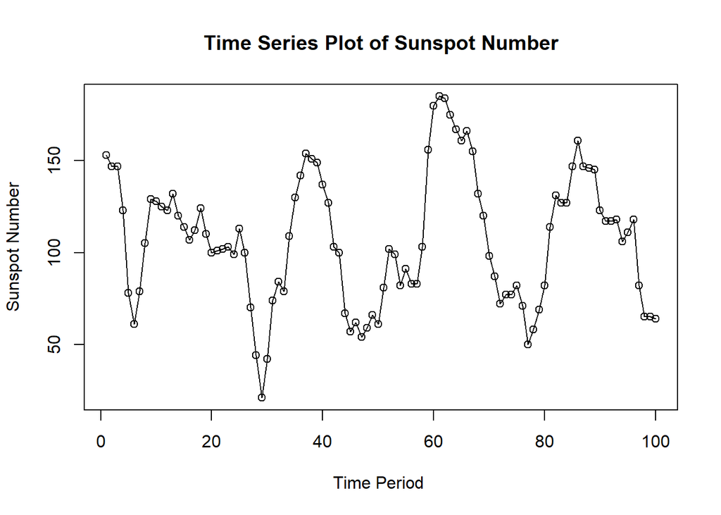

```r
ts.plot(data.ts, xlab="Time Period ", ylab = "Sunspot Number",
        main = "Time Series Plot of Sunspot Number")
points(data.ts)
```

```r
#menyimpan plot
dev.copy(png, "plot_data.png")
```

```r
dev.off()
```

## Single Moving Average & Double Moving Average

### Pembagian Data

Pembagian data latih dan data uji dilakukan dengan perbandingan 80% data latih dan 20% data uji.

```r
# hitung jumlah data
n <- nrow(data)

# tentukan batas 80%
n_train <- floor(0.8 * n)

# bagi data
training_ma <- data[1:n_train, ]
testing_ma  <- data[(n_train+1):n, ]

# ubah ke time series
train_ma.ts <- ts(training_ma$SN)
test_ma.ts  <- ts(testing_ma$SN)
```

Eksplorasi data dilakukan pada keseluruhan data, data latih serta data uji menggunakan plot data deret waktu.

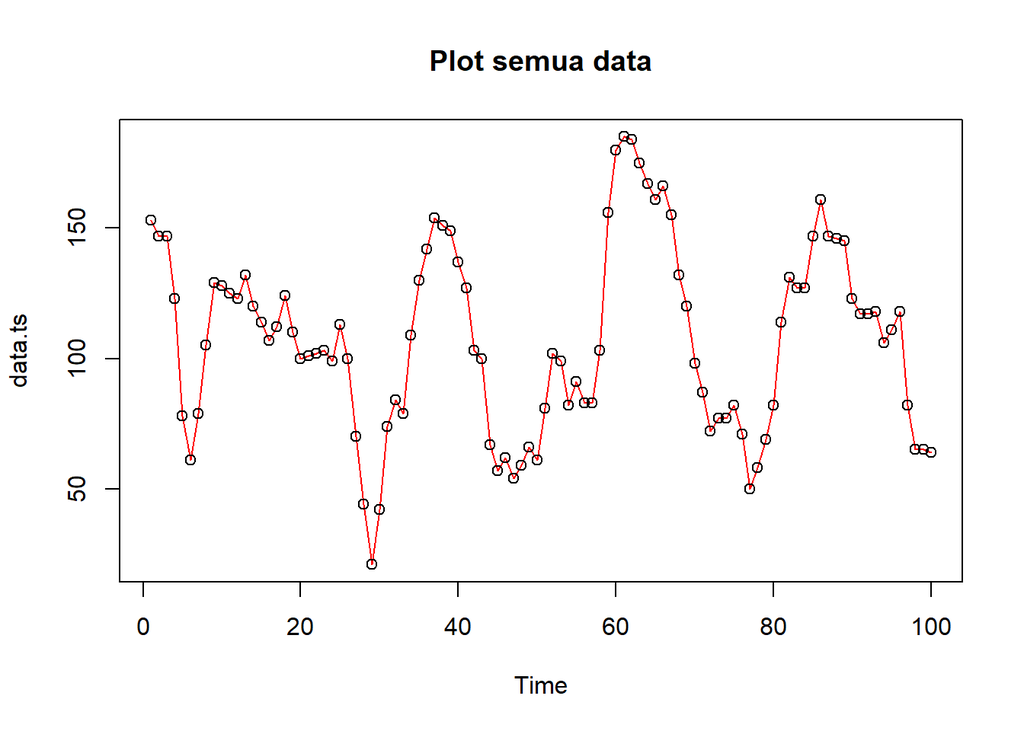

```r
#eksplorasi keseluruhan data
plot(data.ts, col="red",main="Plot semua data")
points(data.ts)
```

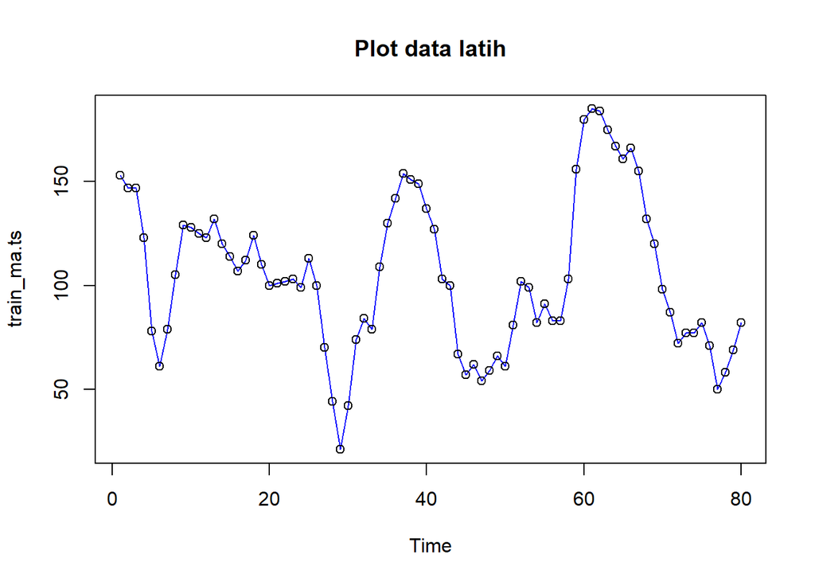

```r
#eksplorasi data latih
plot(train_ma.ts, col="blue",main="Plot data latih")
points(train_ma.ts)
```

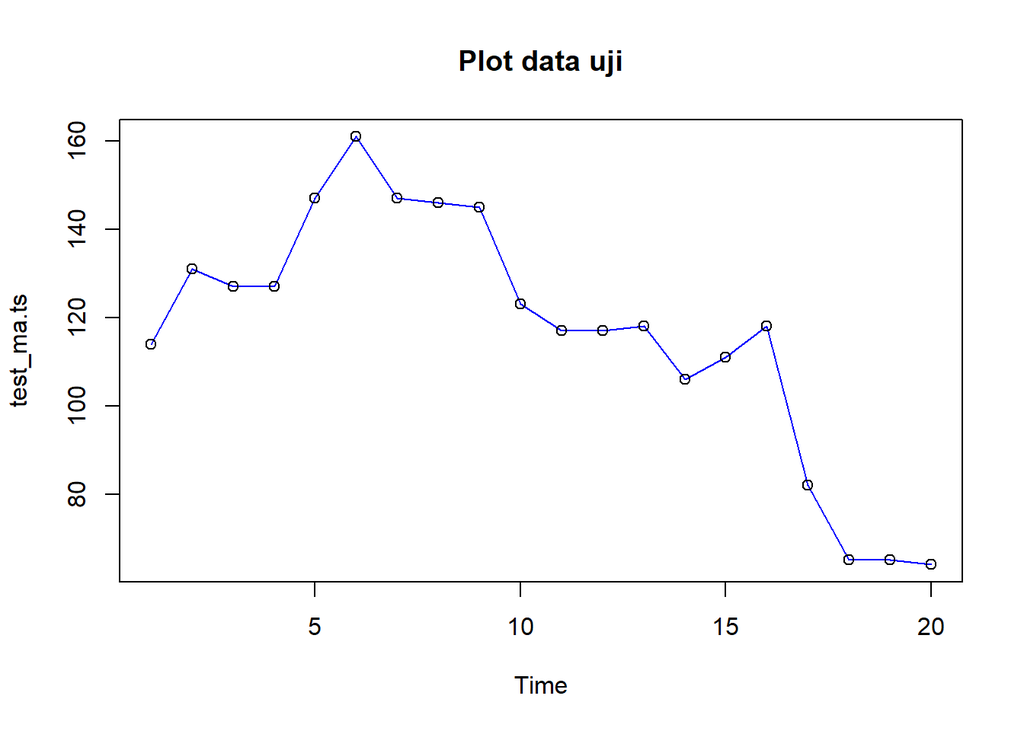

```r
#eksplorasi data uji
plot(test_ma.ts, col="blue",main="Plot data uji")
points(test_ma.ts)
```

Eksplorasi data juga dapat dilakukan menggunakan package `ggplot2` dengan terlebih dahulu memanggil library *package* `ggplot2`.

[figure not shown]

```r
library(ggplot2)
ggplot() +
  geom_line(data = training_ma, aes(x = Date, y = SN, col = "Data Latih")) +
  geom_line(data = testing_ma, aes(x = Date, y = SN, col = "Data Uji")) +
  labs(x = "Time Period", y = "Sunspot Number", color = "Legend") +
   scale_colour_manual(name="Keterangan:", breaks = c("Data Latih", "Data Uji"),
                      values = c("blue", "red")) +
  theme_bw() + theme(legend.position = "bottom",
                     plot.caption = element_text(hjust=0.5, size=12))
```

### Single Moving Average (SMA)

Ide dasar dari Single Moving Average (SMA) adalah data suatu periode dipengaruhi oleh data periode sebelumnya. Metode pemulusan ini cocok digunakan untuk pola data stasioner atau konstan. Prinsip dasar metode pemulusan ini adalah data pemulusan pada periode ke-t merupakan rata rata dari m buah data pada periode ke-t hingga periode ke (t-m+1).

$$S_t = \frac{1}{m} \sum_{i=t-m+1}^{t} X_i$$

Data pemulusan pada periode ke-t selanjutnya digunakan sebagai nilai peramalan pada periode ke t+1.

$$F_t = S_{t-1}, F_{n,h} = S_n$$

Pemulusan menggunakan metode SMA dilakukan dengan fungsi `SMA()`. Dalam hal ini akan dilakukan pemulusan dengan parameter `m=4`.

```r
m <- 4
data.sma <- SMA(train_ma.ts, n=m)
data.sma
```

```
## Time Series:
## Start = 1
## End = 80
## Frequency = 1
##  [1]     NA     NA     NA 142.50 123.75 102.25  85.25  80.75  93.50 110.25
## [11] 121.75 126.25 127.00 125.00 122.25 118.25 113.25 114.25 113.25 111.50
## [21] 108.75 103.25 101.50 101.25 104.25 103.75  95.50  81.75  58.75  44.25
## [31]  45.25  55.25  69.75  86.50 100.50 115.00 133.75 144.25 149.00 147.75
## [41] 141.00 129.00 116.75  99.25  81.75  71.50  60.00  58.00  60.25  60.00
## [51]  66.75  77.50  85.75  91.00  93.50  88.75  84.75  90.00 106.25 130.50
## [61] 156.00 176.25 181.00 177.75 171.75 167.25 162.25 153.50 143.25 126.25
## [71] 109.25  94.25  83.50  78.25  77.00  76.75  70.00  65.25  62.00  64.75
```

Data pemulusan pada periode ke-t selanjutnya digunakan sebagai nilai peramalan pada periode ke t+1 sehingga hasil peramalan 1 periode kedepan adalah sebagai berikut.

```r
data.ramal <- c (NA, data.sma)
data.ramal #forecast 1 periode ke depan
```

```
##  [1]     NA     NA     NA     NA 142.50 123.75 102.25  85.25  80.75  93.50
## [11] 110.25 121.75 126.25 127.00 125.00 122.25 118.25 113.25 114.25 113.25
## [21] 111.50 108.75 103.25 101.50 101.25 104.25 103.75  95.50  81.75  58.75
## [31]  44.25  45.25  55.25  69.75  86.50 100.50 115.00 133.75 144.25 149.00
## [41] 147.75 141.00 129.00 116.75  99.25  81.75  71.50  60.00  58.00  60.25
## [51]  60.00  66.75  77.50  85.75  91.00  93.50  88.75  84.75  90.00 106.25
## [61] 130.50 156.00 176.25 181.00 177.75 171.75 167.25 162.25 153.50 143.25
## [71] 126.25 109.25  94.25  83.50  78.25  77.00  76.75  70.00  65.25  62.00
## [81]  64.75
```

Selanjutnya dilakukan peramalan sebanyak 20 periode sesuai dengan jumlah data uji. Pada metode SMA, seluruh hasil peramalan untuk 20 periode ke depan akan memiliki nilai yang sama dengan hasil ramalan satu periode ke depan.

```r
data.gab <- cbind(
  aktual = c(data.ts),
  pemulusan = c(data.sma, rep(NA, 20)),
  ramalan = c(data.ramal, rep(data.ramal[length(data.ramal)], 19)))

data.gab #forecast 20 periode ke depan
```

```
##        aktual pemulusan ramalan
##   [1,]    153        NA      NA
##   [2,]    147        NA      NA
##   [3,]    147        NA      NA
##   [4,]    123    142.50      NA
##   [5,]     78    123.75  142.50
##   [6,]     61    102.25  123.75
##   [7,]     79     85.25  102.25
##   [8,]    105     80.75   85.25
##   [9,]    129     93.50   80.75
##  [10,]    128    110.25   93.50
##  [11,]    125    121.75  110.25
##  [12,]    123    126.25  121.75
##  [13,]    132    127.00  126.25
##  [14,]    120    125.00  127.00
```

[output cut: 86 more lines]

Adapun plot data deret waktu dari hasil peramalan yang dilakukan adalah sebagai berikut.

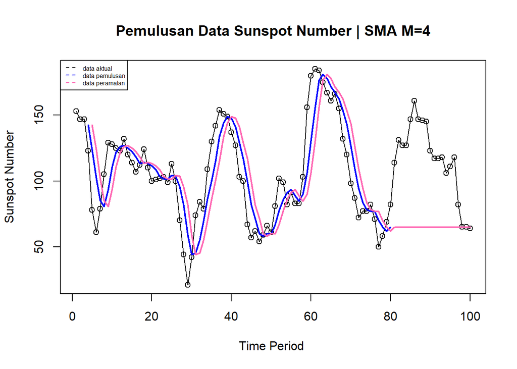

```r
ts.plot(data.ts, xlab="Time Period ", ylab="Sunspot Number", main= "Pemulusan Data Sunspot Number | SMA M=4")
points(data.ts)
lines(data.gab[,2], col="blue", lwd=2)
lines(data.gab[,3], col="hotpink", lwd=2)
legend("topleft", c("data aktual", "data pemulusan", "data peramalan"), lty=8, col = c("black", "blue", "hotpink"), cex = 0.5)
```

Selanjutnya perhitungan akurasi dilakukan dengan ukuran akurasi *Sum Squares Error* (SSE), *Mean Square Error* (MSE) dan *Mean Absolute Percentage Error* (MAPE). Perhitungan akurasi dilakukan baik pada data latih maupun pada data uji.

$$SSE = \sum_{t=1}^{n} (y_t - \hat{y}_t)^2$$
$$MSE = \frac{1}{n} \sum_{t=1}^{n} (y_t - \hat{y}_t)^2$$
$$MAPE = \frac{1}{n} \sum_{t=1}^{n} \left|\frac{y_t -
\hat{y}_t}{y_t}\right| * 100$$

```r
#Menghitung nilai keakuratan data latih
error_train.sma = train_ma.ts-data.ramal[1:length(train_ma.ts)]

SSE_train.sma = sum(error_train.sma[5:length(train_ma.ts)]^2)
MSE_train.sma = mean(error_train.sma[5:length(train_ma.ts)]^2)
MAPE_train.sma = mean(abs((error_train.sma[5:length(train_ma.ts)]/train_ma.ts[5:length(train_ma.ts)])*100))

akurasi_train.sma <- matrix(c(SSE_train.sma, MSE_train.sma, MAPE_train.sma))
row.names(akurasi_train.sma)<- c("SSE", "MSE", "MAPE")
colnames(akurasi_train.sma) <- c("Akurasi m = 4")
akurasi_train.sma
```

```
##      Akurasi m = 4
## SSE    64982.18750
## MSE      855.02878
## MAPE      27.67929
```

Nilai MAPE data latih pada metode pemulusan SMA adalah sekitar 27,68%. Karena nilai tersebut berada pada rentang 20% - 50%, akurasi peramalan ini dapat dikategorikan sebagai cukup. Selanjutnya dilakukan perhitungan nilai MAPE data uji pada metode pemulusan SMA.

```r
#Menghitung nilai keakuratan data uji
error_test.sma = test_ma.ts-data.gab[(n_train + 1):n, 3]

SSE_test.sma = sum(error_test.sma^2)
MSE_test.sma = mean(error_test.sma^2)
MAPE_test.sma = mean(abs((error_test.sma/test_ma.ts*100)))

akurasi_test.sma <- matrix(c(SSE_test.sma, MSE_test.sma, MAPE_test.sma))
row.names(akurasi_test.sma)<- c("SSE", "MSE", "MAPE")
colnames(akurasi_test.sma) <- c("Akurasi m = 4")
akurasi_test.sma
```

```
##      Akurasi m = 4
## SSE    69063.75000
## MSE     3453.18750
## MAPE      40.24882
```

Perhitungan akurasi menggunakan data uji menghasilkan nilai MAPE sebesar 40,25%. Nilai ini berada pada rentang 20% - 50%, sehingga tingkat akurasi peramalan untuk data uji ini juga dapat dikategorikan sebagai cukup.

### Double Moving Average (DMA)

Metode pemulusan Double Moving Average (DMA) pada dasarnya mirip dengan SMA. Namun demikian, metode ini lebih cocok digunakan untuk pola data trend. Proses pemulusan dengan rata rata dalam metode ini dilakukan sebanyak 2 kali.

- **Tahap I:**

$$S_{1,t} = \frac{1}{m} \sum_{i=t-m+1}^{t} X_i$$

- **Tahap II:**

$$S_{2,t} = \frac{1}{m} \sum_{i=t-m+1}^{t} S_{1,i}$$

Forecast $h$ langkah ke depan dihitung dengan:

$$F_{2,t,t+h} = A_t + B_t \,(h)$$

dengan komponen level ($A_t$) dan tren ($B_t$):

$$A_t = 2S_{1,t} - S_{2,t}
\qquad\text{dan}\qquad
B_t = \frac{2}{m-1}\,\big(S_{1,t} - S_{2,t}\big)$$

```r
dma <- SMA(data.sma, n = 4)
At <- 2*data.sma - dma
Bt <- 2/(4-1)*(data.sma - dma)
data.dma<- At+Bt
data.ramal2<- c(NA, data.dma)

t = 1:24
f = c()

for (i in t) {
  f[i] = At[length(At)] + Bt[length(Bt)]*(i)
}

data.gab2 <- cbind(aktual = c(data.ts),
                   pemulusan1 = c(data.sma,rep(NA,24)),
                   pemulusan2 = c(dma, rep(NA,24)),
                   At = c(At, rep(NA,24)),
                   Bt = c(Bt,rep(NA,24)),
                   ramalan = c(data.ramal2, f[-1]))
data.gab2
```

```
##        aktual pemulusan1 pemulusan2       At          Bt    ramalan
##   [1,]    153         NA         NA       NA          NA         NA
##   [2,]    147         NA         NA       NA          NA         NA
##   [3,]    147         NA         NA       NA          NA         NA
##   [4,]    123     142.50         NA       NA          NA         NA
##   [5,]     78     123.75         NA       NA          NA         NA
##   [6,]     61     102.25         NA       NA          NA         NA
##   [7,]     79      85.25   113.4375  57.0625 -18.7916667         NA
##   [8,]    105      80.75    98.0000  63.5000 -11.5000000  38.270833
##   [9,]    129      93.50    90.4375  96.5625   2.0416667  52.000000
##  [10,]    128     110.25    92.4375 128.0625  11.8750000  98.604167
##  [11,]    125     121.75   101.5625 141.9375  13.4583333 139.937500
##  [12,]    123     126.25   112.9375 139.5625   8.8750000 155.395833
##  [13,]    132     127.00   121.3125 132.6875   3.7916667 148.437500
##  [14,]    120     125.00   125.0000 125.0000   0.0000000 136.479167
```

[output cut: 90 more lines]

Hasil pemulusan menggunakan metode DMA divisualisasikan sebagai berikut

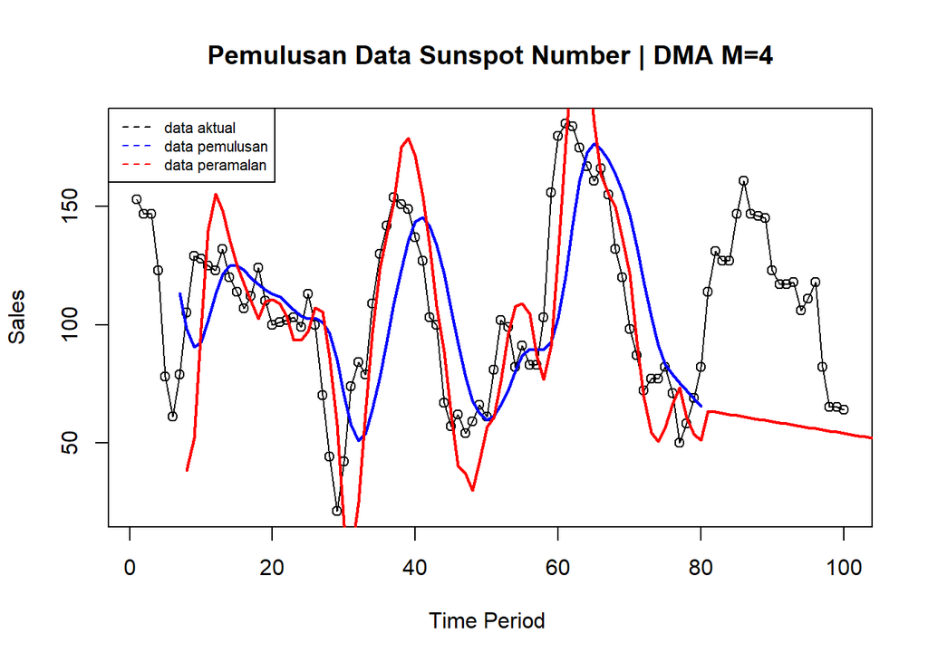

```r
ts.plot(data.ts, xlab="Time Period ", ylab="Sales", main= "Pemulusan Data Sunspot Number | DMA M=4")
points(data.ts)
lines(data.gab2[,3],col="blue",lwd=2)
lines(data.gab2[,6],col="red",lwd=2)
legend("topleft",c("data aktual","data pemulusan","data peramalan"), lty=8, col=c("black","blue","red"), cex=0.7)
```

Selanjutnya perhitungan akurasi dilakukan baik pada data latih maupun data uji. Perhitungan akurasi dilakukan dengan ukuran akurasi SSE, MSE dan MAPE.

```r
#Menghitung nilai keakuratan data latih
error_train.dma = train_ma.ts-data.ramal2[1:length(train_ma.ts)]

SSE_train.dma = sum(error_train.dma[8:length(train_ma.ts)]^2)
MSE_train.dma = mean(error_train.dma[8:length(train_ma.ts)]^2)
MAPE_train.dma = mean(abs((error_train.dma[8:length(train_ma.ts)]/train_ma.ts[8:length(train_ma.ts)])*100))

akurasi_train.dma <- matrix(c(SSE_train.dma, MSE_train.dma, MAPE_train.dma))
row.names(akurasi_train.dma)<- c("SSE", "MSE", "MAPE")
colnames(akurasi_train.dma) <- c("Akurasi m = 4")
akurasi_train.dma
```

```
##      Akurasi m = 4
## SSE    57937.77734
## MSE      793.66818
## MAPE      25.00596
```

Perhitungan akurasi menggunakan data latih pada metode DMA menghasilkan nilai MAPE sebesar 25,01%. Karena nilai tersebut berada pada rentang 20% - 50%, nilai akurasi ini dapat dikategorikan sebagai cukup. Selanjutnya, perhitungan nilai akurasi dilakukan pada data uji.

```r
#Menghitung nilai keakuratan data uji
error_test.dma = test_ma.ts - data.gab2[(n_train + 1):n, 6]
SSE_test.dma = sum(error_test.dma^2)
MSE_test.dma = mean(error_test.dma^2)
MAPE_test.dma = mean(abs((error_test.dma/test_ma.ts*100)))

akurasi_test.dma <- matrix(c(SSE_test.dma, MSE_test.dma, MAPE_test.dma))
row.names(akurasi_test.dma)<- c("SSE", "MSE", "MAPE")
colnames(akurasi_test.dma) <- c("Akurasi m = 4")
akurasi_test.dma
```

```
##      Akurasi m = 4
## SSE    79945.50000
## MSE     3997.27500
## MAPE      46.31214
```

Jika dibandingkan antara kedua metode: Pada data latih, metode DMA lebih baik dibandingkan metode SMA (karena MAPE DMA lebih kecil). Sebaliknya pada data uji, metode SMA justru lebih baik dibandingkan metode DMA.

## Single Exponential Smoothing & Double Exponential Smoothing

Metode Exponential Smoothing merupakan metode pemulusan deret waktu dengan memberikan bobot yang menurun secara eksponensial pada data historis, di mana nilai terbaru mendapat bobot lebih besar dibanding nilai yang lebih lama. Metode ini menggunakan satu atau lebih parameter pemulusan yang secara langsung menentukan besar kecilnya bobot setiap pengamatan. Pemilihan parameter yang tepat akan sangat berpengaruh terhadap hasil ramalan. Secara umum, Exponential Smoothing dibedakan menjadi dua jenis, yaitu model tunggal (single) yang digunakan untuk data tanpa tren maupun musiman, serta model ganda (double) yang mampu menangkap adanya tren pada data.

### Pembagian Data

Pembagian data latih dan data uji dilakukan dengan perbandingan 80% data latih dan 20% data uji.

```r
# jumlah baris data
n <- nrow(data)

# hitung batas 80%
n_train <- floor(0.8 * n)

# bagi data
training <- data[1:n_train, ]
testing  <- data[(n_train+1):n, ]

# ubah ke time series
train.ts <- ts(training$SN)
test.ts  <- ts(testing$SN)
```

### Eksplorasi

Eksplorasi dilakukan dengan membuat plot data deret waktu untuk keseluruhan data, data latih, dan data uji.

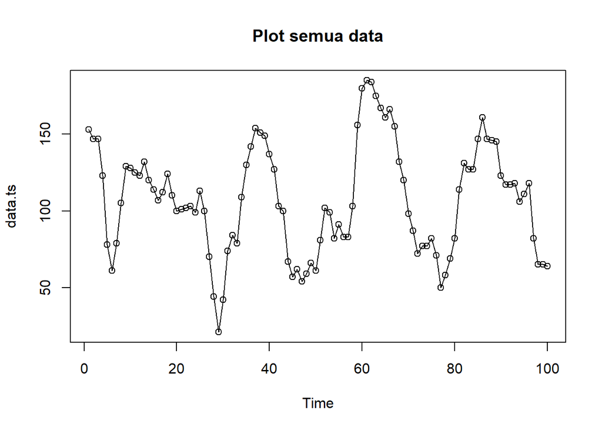

```r
#eksplorasi data
plot(data.ts, col="black",main="Plot semua data")
points(data.ts)
```

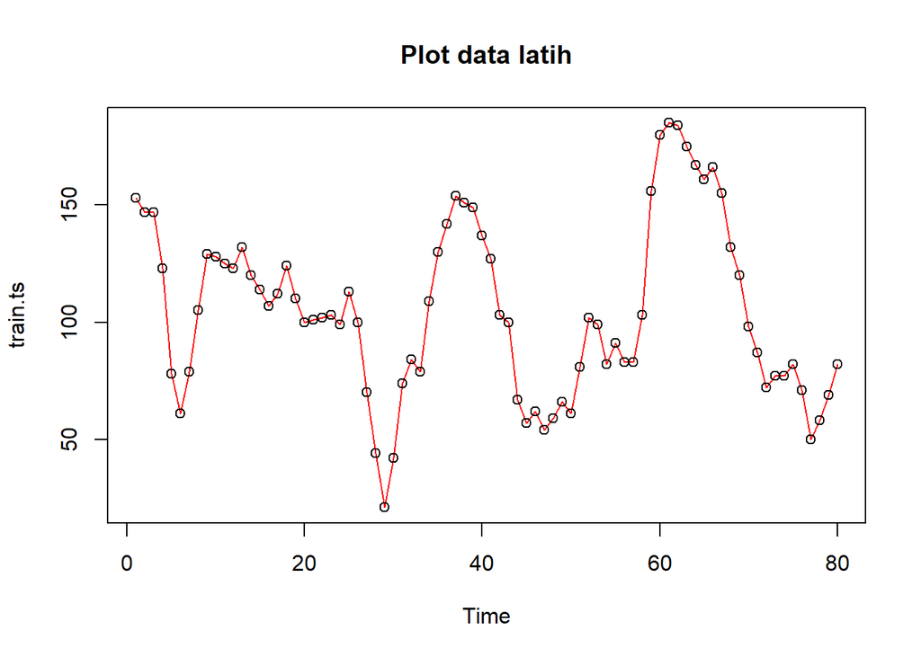

```r
plot(train.ts, col="red",main="Plot data latih")
points(train.ts)
```

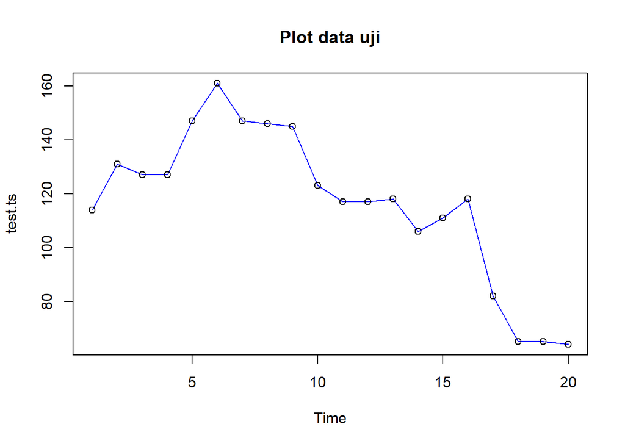

```r
plot(test.ts, col="blue",main="Plot data uji")
points(test.ts)
```

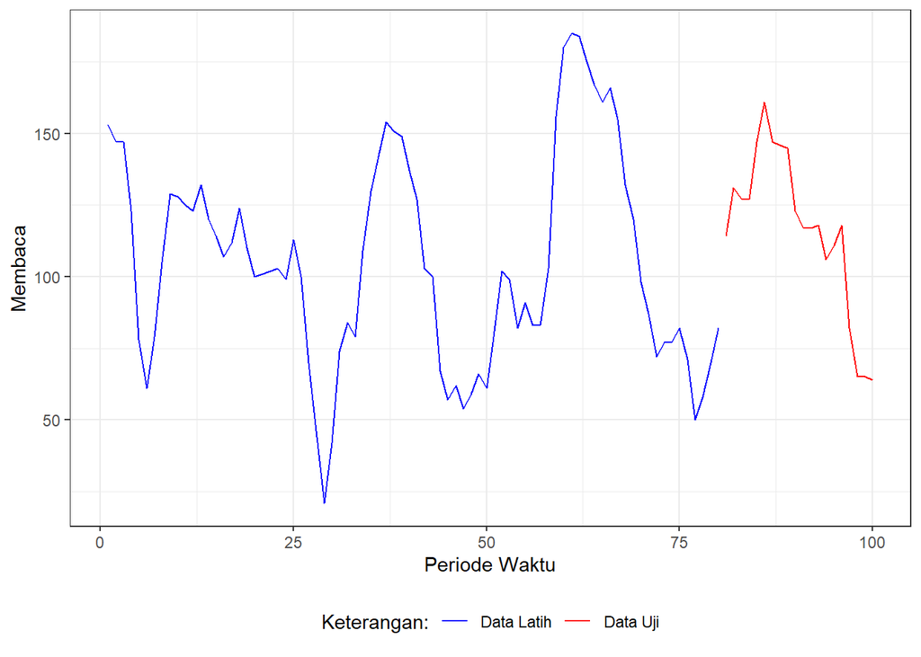

```r
#Eksplorasi dengan GGPLOT
library(ggplot2)
ggplot() +
  geom_line(data = training, aes(x = Periode, y = SN, col = "Data Latih")) +
  geom_line(data = testing, aes(x = Periode, y = SN, col = "Data Uji")) +
  labs(x = "Periode Waktu", y = "Membaca", color = "Legend") +
  scale_colour_manual(name="Keterangan:", breaks = c("Data Latih", "Data Uji"),
                      values = c("blue", "red")) +
  theme_bw() + theme(legend.position = "bottom",
                     plot.caption = element_text(hjust=0.5, size=12))
```

## Single Exponential Smoothing

Single Exponential Smoothing (SES) adalah metode peramalan deret waktu yang dikembangkan untuk mengatasi kelemahan Moving Average. Jika pada Moving Average setiap data periode sebelumnya dianggap memiliki bobot yang sama, maka SES memberikan bobot yang semakin mengecil secara eksponensial terhadap data lama, sehingga data terbaru diberi bobot lebih besar.

Single Exponential Smoothing merupakan metode pemulusan yang tepat digunakan untuk data dengan pola stasioner atau konstan.

Nilai pemulusan pada periode ke-t didapat dari persamaan:

$$\tilde{y}_T=\lambda
y_t+(1-\lambda)\tilde{y}_{T-1}$$

Nilai parameter $\lambda$ adalah nilai antara 0 dan 1.

Nilai pemulusan periode ke-t bertindak sebagai nilai ramalan pada periode ke-$(T+\tau)$.

$$\tilde{y}_{T+\tau}(T)=\tilde{y}_T$$

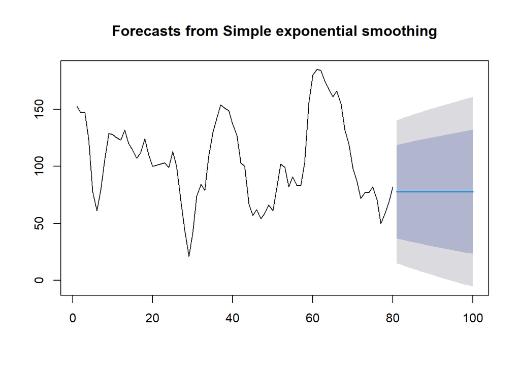

```r
#Cara 1 (fungsi ses)
ses.1 <- ses(train.ts, h = 20, alpha = 0.2)
plot(ses.1)
```

```r
ses.1
```

```
##     Point Forecast    Lo 80    Hi 80      Lo 95    Hi 95
##  81       77.74648 36.72503 118.7679 15.0095890 140.4834
##  82       77.74648 35.91265 119.5803 13.7671537 141.7258
##  83       77.74648 35.11574 120.3772 12.5483904 142.9446
##  84       77.74648 34.33346 121.1595 11.3519954 144.1410
##  85       77.74648 33.56503 121.9279 10.1767806 145.3162
##  86       77.74648 32.80973 122.6832  9.0216593 146.4713
##  87       77.74648 32.06693 123.4260  7.8856349 147.6073
##  88       77.74648 31.33601 124.1569  6.7677904 148.7252
##  89       77.74648 30.61642 124.8765  5.6672800 149.8257
##  90       77.74648 29.90766 125.5853  4.5833215 150.9096
##  91       77.74648 29.20925 126.2837  3.5151897 151.9778
##  92       77.74648 28.52074 126.9722  2.4622110 153.0307
##  93       77.74648 27.84173 127.6512  1.4237583 154.0692
##  94       77.74648 27.17184 128.3211  0.3992464 155.0937
##  95       77.74648 26.51071 128.9822 -0.6118714 156.1048
##  96       77.74648 25.85800 129.6350 -1.6101072 157.1031
##  97       77.74648 25.21339 130.2796 -2.5959411 158.0889
##  98       77.74648 24.57661 130.9164 -3.5698242 159.0628
##  99       77.74648 23.94735 131.5456 -4.5321808 160.0251
## 100       77.74648 23.32538 132.1676 -5.4834108 160.9764
```

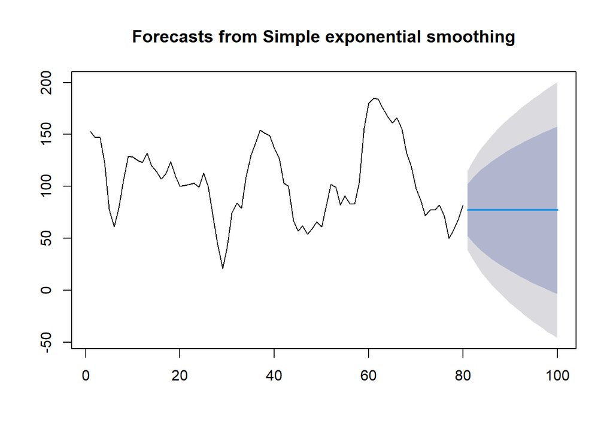

```r
ses.2<- ses(train.ts, h =20, alpha = 0.7)
plot(ses.2)
```

```r
ses.2
```

```
##     Point Forecast     Lo 80    Hi 80      Lo 95    Hi 95
##  81       77.08727 51.958706 102.2158  38.656449 115.5181
##  82       77.08727 46.413949 107.7606  30.176476 123.9981
##  83       77.08727 41.728247 112.4463  23.010313 131.1642
##  84       77.08727 37.594633 116.5799  16.688496 137.4860
##  85       77.08727 33.854456 120.3201  10.968388 143.2061
##  86       77.08727 30.413036 123.7615   5.705191 148.4693
##  87       77.08727 27.208497 126.9660   0.804272 153.3703
##  88       77.08727 24.197764 129.9768  -3.800247 157.9748
##  89       77.08727 21.349422 132.8251  -8.156410 162.3309
##  90       77.08727 18.639725 135.5348 -12.300535 166.4751
##  91       77.08727 16.050204 138.1243 -16.260865 170.4354
##  92       77.08727 13.566161 140.6084 -20.059881 174.2344
##  93       77.08727 11.175669 142.9989 -23.715823 177.8904
##  94       77.08727  8.868893 145.3056 -27.243733 181.4183
##  95       77.08727  6.637608 147.5369 -30.656188 184.8307
##  96       77.08727  4.474856 149.6997 -33.963832 188.1384
##  97       77.08727  2.374684 151.7998 -37.175768 191.3503
##  98       77.08727  0.331955 153.8426 -40.299853 194.4744
##  99       77.08727 -1.657801 155.8323 -43.342922 197.5175
## 100       77.08727 -3.598504 157.7730 -46.310970 200.4855
```

Untuk mendapatkan gambar hasil pemulusan pada data latih dengan fungsi `ses()` , perlu digunakan fungsi `autoplot()` dan `autolayer()` dari *library packages* `ggplot2` .

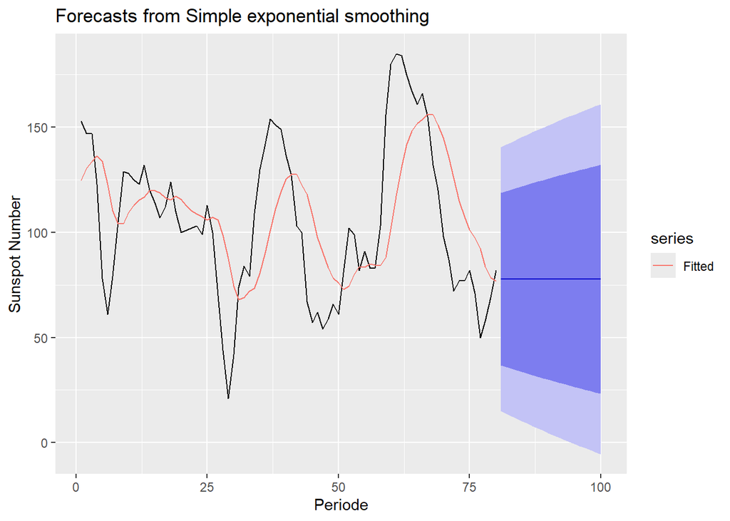

```r
autoplot(ses.1) +
  autolayer(fitted(ses.1), series="Fitted") +
  ylab("Sunspot Number") + xlab("Periode")
```

Selanjutnya akan digunakan fungsi `HoltWinters()` dengan nilai inisialisasi parameter dan panjang periode peramalan yang sama dengan fungsi `ses()` .

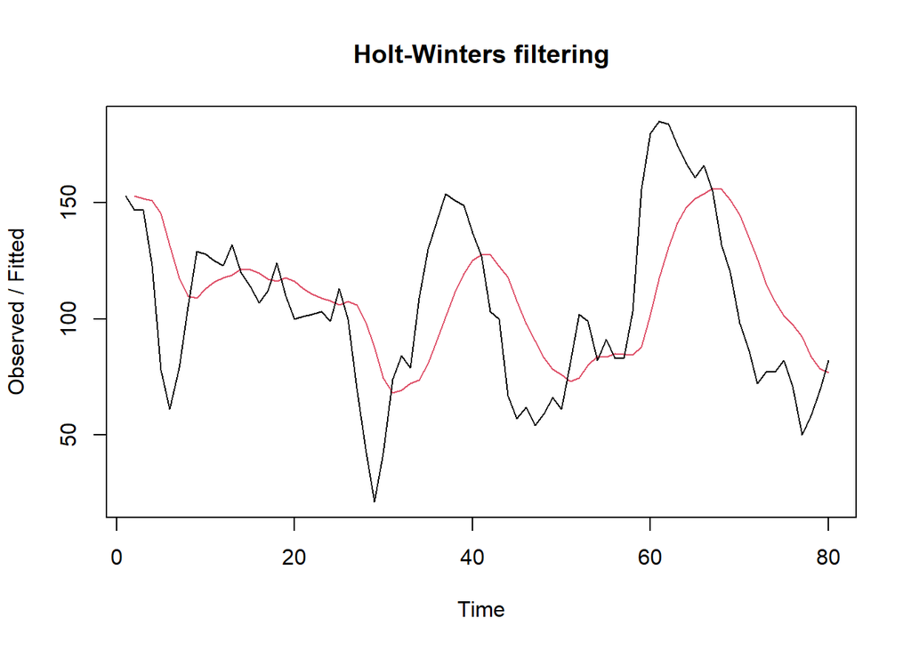

```r
#Cara 2 (fungsi Holtwinter)
ses1<- HoltWinters(train.ts, gamma = FALSE, beta = FALSE, alpha = 0.2)
plot(ses1)
```

```r
#ramalan
ramalan1<- forecast(ses1, h=20)
ramalan1
```

```
##     Point Forecast    Lo 80    Hi 80      Lo 95    Hi 95
##  81       77.74648 36.62110 118.8719 14.8506350 140.6423
##  82       77.74648 35.80665 119.6863 13.6050518 141.8879
##  83       77.74648 35.00773 120.4852 12.3832006 143.1098
##  84       77.74648 34.22347 121.2695 11.1837743 144.3092
##  85       77.74648 33.45309 122.0399 10.0055819 145.4874
##  86       77.74648 32.69588 122.7971  8.8475340 146.6454
##  87       77.74648 31.95119 123.5418  7.7086313 147.7843
##  88       77.74648 31.21842 124.2745  6.5879545 148.9050
##  89       77.74648 30.49701 124.9959  5.4846558 150.0083
##  90       77.74648 29.78645 125.7065  4.3979509 151.0950
##  91       77.74648 29.08627 126.4067  3.3271128 152.1658
##  92       77.74648 28.39602 127.0969  2.2714662 153.2215
##  93       77.74648 27.71529 127.7777  1.2303824 154.2626
##  94       77.74648 27.04370 128.4493  0.2032747 155.2897
##  95       77.74648 26.38089 129.1121 -0.8104050 156.3034
##  96       77.74648 25.72653 129.7664 -1.8111699 157.3041
##  97       77.74648 25.08029 130.4127 -2.7995016 158.2925
##  98       77.74648 24.44189 131.0511 -3.7758522 159.2688
##  99       77.74648 23.81105 131.6819 -4.7406471 160.2336
## 100       77.74648 23.18749 132.3055 -5.6942872 161.1872
```

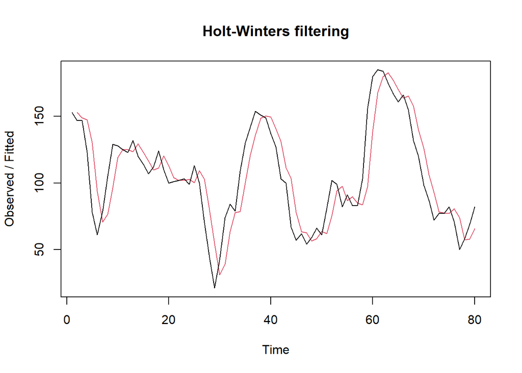

```r
ses2<- HoltWinters(train.ts, gamma = FALSE, beta = FALSE, alpha = 0.7)
plot(ses2)
```

```r
#ramalan
ramalan2<- forecast(ses2, h=20)
ramalan2
```

```
##     Point Forecast      Lo 80    Hi 80       Lo 95    Hi 95
##  81       77.08727 52.0174496 102.1571  38.7462901 115.4282
##  82       77.08727 46.4856550 107.6889  30.2861403 123.8884
##  83       77.08727 41.8109071 112.3636  23.1367304 131.0378
##  84       77.08727 37.6869564 116.4876  16.8296920 137.3448
##  85       77.08727 33.9555225 120.2190  11.1229563 143.0516
##  86       77.08727 30.5221481 123.6524   5.8720634 148.3025
##  87       77.08727 27.3251006 126.8494   0.9826011 153.1919
##  88       77.08727 24.3214057 129.8531  -3.6111537 157.7857
##  89       77.08727 21.4797223 132.6948  -7.9571335 162.1317
##  90       77.08727 18.7763595 135.3982 -12.0915701 166.2661
##  91       77.08727 16.1928925 137.9816 -16.0426419 170.2172
##  92       77.08727 13.7146566 140.4599 -19.8327767 174.0073
##  93       77.08727 11.3297529 142.8448 -23.4801721 177.6547
##  94       77.08727  9.0283692 145.1462 -26.9998348 181.1744
##  95       77.08727  6.8023008 147.3722 -30.4043127 184.5788
##  96       77.08727  4.6446043 149.5299 -33.7042247 187.8788
##  97       77.08727  2.5493418 151.6252 -36.9086521 191.0832
##  98       77.08727  0.5113883 153.6631 -40.0254331 194.2000
##  99       77.08727 -1.4737164 155.6482 -43.0613887 197.2359
## 100       77.08727 -3.4098821 157.5844 -46.0224987 200.1970
```

Nilai parameter $\alpha$ dari kedua fungsi dapat dioptimalkan menyesuaikan dari *error*-nya paling minimumnya. Caranya adalah dengan membuat parameter $\alpha =$ `NULL` .

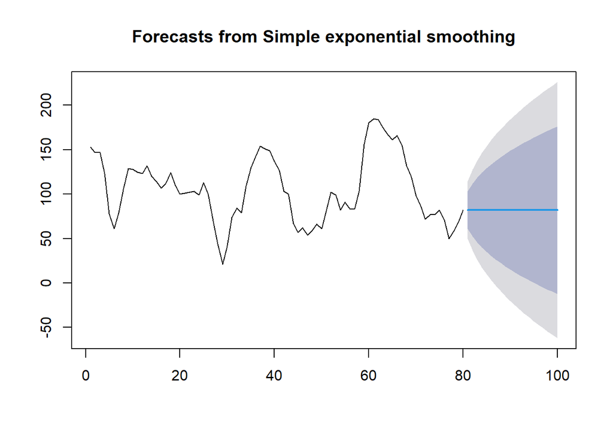

```r
#SES
ses.opt <- ses(train.ts, h = 20, alpha = NULL)
plot(ses.opt)
```

```r
ses.opt
```

```
##     Point Forecast       Lo 80    Hi 80      Lo 95    Hi 95
##  81        81.9987  60.9151644 103.0822  49.754215 114.2432
##  82        81.9987  52.1835693 111.8138  36.400393 127.5970
##  83        81.9987  45.4833803 118.5140  26.153338 137.8441
##  84        81.9987  39.8347923 124.1626  17.514568 146.4828
##  85        81.9987  34.8582538 129.1391   9.903609 154.0938
##  86        81.9987  30.3591008 133.6383   3.022748 160.9747
##  87        81.9987  26.2216908 137.7757  -3.304874 167.3023
##  88        81.9987  22.3706755 141.6267  -9.194494 173.1919
##  89        81.9987  18.7537172 145.2437 -14.726154 178.7236
##  90        81.9987  15.3327087 148.6647 -19.958135 183.9555
##  91        81.9987  12.0788821 151.9185 -24.934434 188.9318
##  92        81.9987   8.9698873 155.0275 -29.689231 193.6866
##  93        81.9987   5.9879505 158.0094 -34.249709 198.2471
##  94        81.9987   3.1186608 160.8787 -38.637909 202.6353
##  95        81.9987   0.3501414 163.6473 -42.871995 206.8694
##  96        81.9987  -2.3275336 166.3249 -46.967145 210.9645
##  97        81.9987  -4.9227600 168.9202 -50.936201 214.9336
##  98        81.9987  -7.4427152 171.4401 -54.790140 218.7875
##  99        81.9987  -9.8935919 173.8910 -58.538433 222.5358
## 100        81.9987 -12.2807774 176.2782 -62.189318 226.1867
```

```r
#Lamda Optimum Holt Winter
HWopt<- HoltWinters(train.ts, gamma = FALSE, beta = FALSE,alpha = NULL)
HWopt
```

```
## Holt-Winters exponential smoothing without trend and without seasonal component.
##
## Call:
## HoltWinters(x = train.ts, alpha = NULL, beta = FALSE, gamma = FALSE)
##
## Smoothing parameters:
##  alpha: 0.9999566
##  beta : FALSE
##  gamma: FALSE
##
## Coefficients:
##       [,1]
## a 81.99944
```

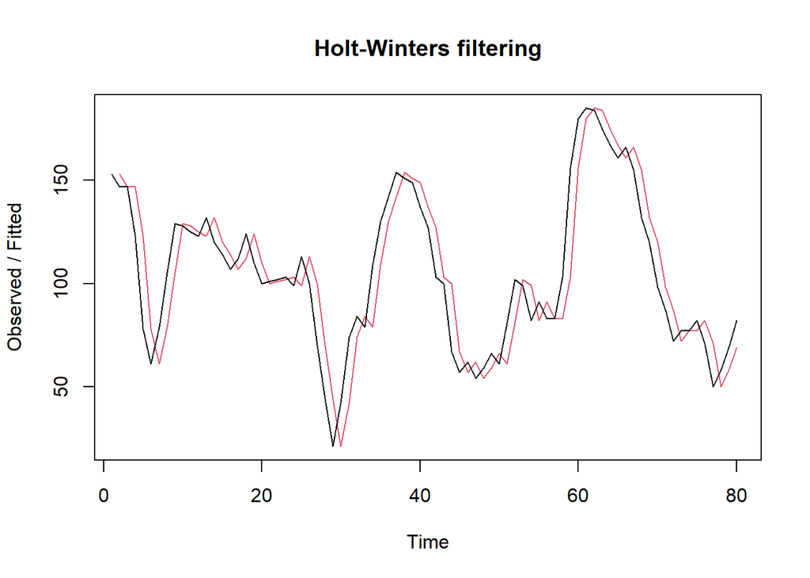

```r
plot(HWopt)
```

```r
#ramalan
ramalanopt<- forecast(HWopt, h = 20)
ramalanopt
```

```
##     Point Forecast       Lo 80    Hi 80      Lo 95    Hi 95
##  81       81.99944  60.9483637 103.0505  49.804600 114.1943
##  82       81.99944  52.2293709 111.7695  36.470051 127.5288
##  83       81.99944  45.5389655 118.4599  26.237959 137.7609
##  84       81.99944  39.8986636 124.1002  17.611861 146.3870
##  85       81.99944  34.9294438 129.0694  10.012095 153.9868
##  86       81.99944  30.4369177 133.5620   3.141370 160.8575
##  87       81.99944  26.3056085 137.6933  -3.176923 167.1758
##  88       81.99944  22.4602762 141.5386  -9.057851 173.0567
##  89       81.99944  18.8486586 145.1502 -14.581343 178.5802
##  90       81.99944  15.4327040 148.5662 -19.805595 183.8045
##  91       81.99944  12.1836861 151.8152 -24.774539 188.7734
##  92       81.99944   9.0792875 154.9196 -29.522307 193.5212
##  93       81.99944   6.1017602 157.8971 -34.076042 198.0749
##  94       81.99944   3.2367144 160.7622 -38.457752 202.4566
##  95       81.99944   0.4722906 163.5266 -42.685573 206.6844
##  96       81.99944  -2.2014225 166.2003 -46.774664 210.7735
##  97       81.99944  -4.7928084 168.7917 -50.737847 214.7367
##  98       81.99944  -7.3090340 171.3079 -54.586082 218.5850
##  99       81.99944  -9.7562829 173.7552 -58.328826 222.3277
## 100       81.99944 -12.1399345 176.1388 -61.974307 225.9732
```

Setelah dilakukan peramalan, akan dilakukan perhitungan keakuratan hasil peramalan. Perhitungan akurasi ini dilakukan baik pada data latih dan data uji.

#### Akurasi Data Latih

Perhitungan akurasi data dapat dilakukan dengan cara langsung maupun manual. Secara langsung, nilai akurasi dapat diambil dari objek yang tersimpan pada hasil SES, yaitu *sum of squared errors* (SSE). Nilai akurasi lain dapat dihitung pula dari nilai SSE tersebut.

```r
#Keakuratan Metode
#Pada data training

# SES dengan alpha = 0.2
SSE1<-ses1$SSE
MSE1<-ses1$SSE/length(train.ts)
RMSE1<-sqrt(MSE1)

akurasi1 <- matrix(c(SSE1,MSE1,RMSE1))
row.names(akurasi1)<- c("SSE", "MSE", "RMSE")
colnames(akurasi1) <- c("Akurasi lamda=0.2")
akurasi1
```

```
##      Akurasi lamda=0.2
## SSE        82115.56160
## MSE         1026.44452
## RMSE          32.03817
```

```r
# SES dengan alpha = 0.7
SSE2<-ses2$SSE
MSE2<-ses2$SSE/length(train.ts)
RMSE2<-sqrt(MSE2)

akurasi2 <- matrix(c(SSE2,MSE2,RMSE2))
row.names(akurasi2)<- c("SSE", "MSE", "RMSE")
colnames(akurasi2) <- c("Akurasi lamda=0.7")
akurasi2
```

```
##      Akurasi lamda=0.7
## SSE        29997.52434
## MSE          374.96905
## RMSE          19.36412
```

Berdasarkan nilai SSE, MSE, dan RMSE di antara kedua parameter, nilai parameter $\lambda=0,7$ menghasilkan akurasi yang lebih baik dibandingkan $\lambda=0,2$. Hal ini dapat dilihat dari nilai masing-masing ukuran kesalahan (error) pada $\lambda=0,7$ yang lebih kecil. Oleh karena itu, model pemulusan dengan parameter 0,7 lebih layak digunakan dibandingkan parameter 0,2.

#### Akurasi Data Uji

Akurasi data uji dapat dihitung dengan cara yang hampir sama dengan perhitungan akurasi data latih.

```r
# jumlah observasi uji
n_test <- nrow(testing)

# error (ramalan - aktual), samakan panjang dan tipe numeric
e1   <- as.numeric(ramalan1$mean)[1:n_test] - as.numeric(testing$SN)
e2   <- as.numeric(ramalan2$mean)[1:n_test] - as.numeric(testing$SN)
eopt <- as.numeric(ramalanopt$mean)[1:n_test] - as.numeric(testing$SN)

# SSE / MSE / RMSE untuk masing-masing model (abaikan NA)
SSEtesting1  <- sum(e1^2,  na.rm = TRUE)
MSEtesting1  <- mean(e1^2, na.rm = TRUE)
RMSEtesting1 <- sqrt(MSEtesting1)

SSEtesting2  <- sum(e2^2,  na.rm = TRUE)
MSEtesting2  <- mean(e2^2, na.rm = TRUE)
RMSEtesting2 <- sqrt(MSEtesting2)

SSEtestingopt  <- sum(eopt^2,  na.rm = TRUE)
MSEtestingopt  <- mean(eopt^2, na.rm = TRUE)
RMSEtestingopt <- sqrt(MSEtestingopt)

# Tabel ringkas
akurasitesting_SSE <- matrix(c(SSEtesting1, SSEtesting2, SSEtestingopt),
                             nrow = 3,
                             dimnames = list(c("SSE1","SSE2","SSEopt"), "Nilai"))
akurasitesting_MSE <- matrix(c(MSEtesting1, MSEtesting2, MSEtestingopt),
                             nrow = 3,
                             dimnames = list(c("MSE1","MSE2","MSEopt"), "Nilai"))
akurasitesting_RMSE <- matrix(c(RMSEtesting1, RMSEtesting2, RMSEtestingopt),
                              nrow = 3,
                              dimnames = list(c("RMSE1","RMSE2","RMSEopt"), "Nilai"))

akurasitesting_SSE
```

```
##           Nilai
## SSE1   45513.21
## SSE2   46545.10
## SSEopt 39273.78
```

```r
akurasitesting_MSE
```

```
##           Nilai
## MSE1   2275.661
## MSE2   2327.255
## MSEopt 1963.689
```

```r
akurasitesting_RMSE
```

```
##            Nilai
## RMSE1   47.70389
## RMSE2   48.24163
## RMSEopt 44.31353
```

Berdasarkan perbandingan nilai evaluasi akurasi di atas, terlihat bahwa model dengan parameter optimal menghasilkan tingkat kesalahan yang paling rendah dibandingkan dengan percobaan parameter pertama dan kedua. Hal ini menunjukkan bahwa pencarian parameter secara otomatis (optimal) memberikan kinerja peramalan yang paling baik di antara model lainnya.

## *Double Exponential Smoothing* (DES)

Metode pemulusan *Double Exponential Smoothing* (DES) digunakan untuk data yang memiliki pola tren. Metode DES adalah metode semacam SES, hanya saja dilakukan dua kali, yaitu pertama untuk tahapan ‘level’ dan kedua untuk tahapan ‘tren’. Pemulusan menggunakan metode ini akan menghasilkan peramalan tidak konstan untuk periode berikutnya.

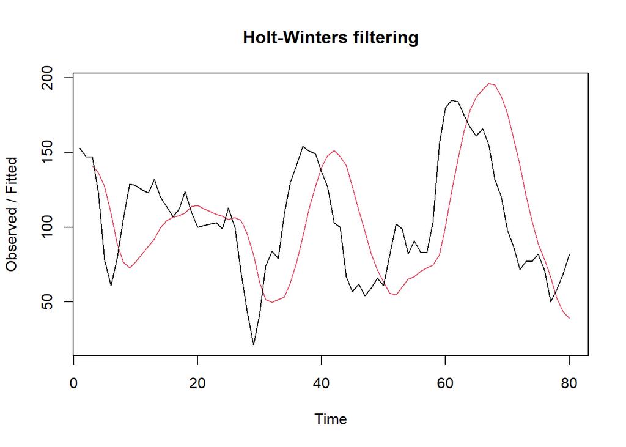

```r
#Lamda=0.2 dan gamma=0.2
des.1<- HoltWinters(train.ts, gamma = FALSE, beta = 0.2, alpha = 0.2)
plot(des.1)
```

```r
#ramalan
ramalandes1<- forecast(des.1, h=20)
ramalandes1
```

```
##     Point Forecast      Lo 80    Hi 80      Lo 95     Hi 95
##  81      39.962702  -11.27826 91.20366  -38.40359 118.32899
##  82      32.290506  -20.40554 84.98655  -48.30114 112.88215
##  83      24.618309  -29.99600 79.23262  -58.90707 108.14369
##  84      16.946113  -40.07658 73.96881  -70.26257 104.15480
##  85       9.273916  -50.65830 69.20613  -82.38450 100.93233
##  86       1.601720  -61.73841 64.94185  -95.26865  98.47209
##  87      -6.070477  -73.30362 61.16266 -108.89469  96.75374
##  88     -13.742673  -85.33347 57.84812 -123.23134  95.74600
##  89     -21.414870  -97.80344 54.97370 -138.24111  95.41137
##  90     -29.087066 -110.68739 52.51326 -153.88400  95.70986
##  91     -36.759262 -123.95928 50.44075 -170.12017  96.60165
##  92     -44.431459 -137.59424 48.73132 -186.91163  98.04871
##  93     -52.103655 -151.56921 47.36190 -204.22310 100.01579
##  94     -59.775852 -165.86321 46.31150 -222.02246 102.47076
##  95     -67.448048 -180.45732 45.56122 -240.28081 105.38471
##  96     -75.120245 -195.33464 45.09415 -258.97230 108.73181
##  97     -82.792441 -210.48015 44.89527 -278.07394 112.48905
##  98     -90.464638 -225.88045 44.95118 -297.56526 116.63598
##  99     -98.136834 -241.52366 45.24999 -317.42806 121.15439
## 100    -105.809031 -257.39916 45.78110 -337.64613 126.02807
```

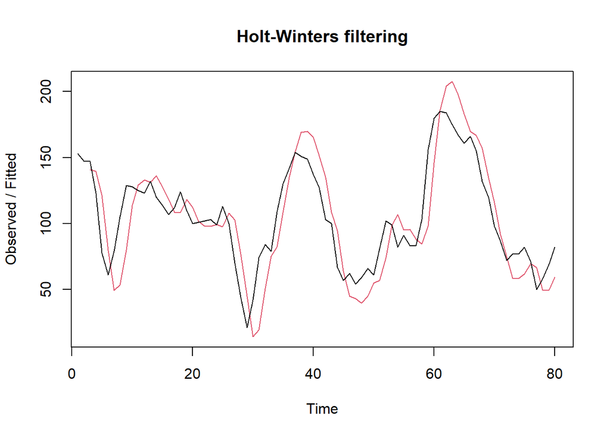

```r
#Lamda=0.6 dan gamma=0.3
des.2<- HoltWinters(train.ts, gamma = FALSE, beta = 0.3, alpha = 0.6)
plot(des.2)
```

```r
#ramalan
ramalandes2<- forecast(des.2, h=20)
ramalandes2
```

```
##     Point Forecast       Lo 80    Hi 80       Lo 95    Hi 95
##  81       75.09704   46.597803 103.5963   31.511220 118.6829
##  82       77.31694   41.173436 113.4604   22.040222 132.5937
##  83       79.53684   34.206031 124.8676   10.209351 148.8643
##  84       81.75674   25.985550 137.5279   -3.537933 167.0514
##  85       83.97664   16.703956 151.2493  -18.908050 186.8613
##  86       86.19654    6.490341 165.9027  -35.703572 208.0966
##  87       88.41644   -4.564469 181.3973  -53.785588 230.6185
##  88       90.63634  -16.393368 197.6660  -73.051473 254.3242
##  89       92.85624  -28.944566 214.6570  -93.422017 279.1345
##  90       95.07614  -42.176598 232.3289 -114.833808 304.9861
##  91       97.29604  -56.055264 250.6473 -137.234541 331.8266
##  92       99.51594  -70.551672 269.5836 -160.580028 359.6119
##  93      101.73584  -85.640934 289.1126 -184.832207 388.3039
##  94      103.95574 -101.301275 309.2128 -209.957776 417.8693
##  95      106.17564 -117.513393 329.8647 -235.927215 448.2785
##  96      108.39554 -134.259999 351.0511 -262.714082 479.5052
##  97      110.61544 -151.525465 372.7563 -290.294478 511.5254
##  98      112.83534 -169.295560 394.9662 -318.646638 544.3173
##  99      115.05524 -187.557242 417.6677 -347.750615 577.8611
## 100      117.27514 -206.298489 440.8488 -377.588023 612.1383
```

Selanjutnya jika ingin membandingkan plot data latih dan data uji adalah sebagai berikut.

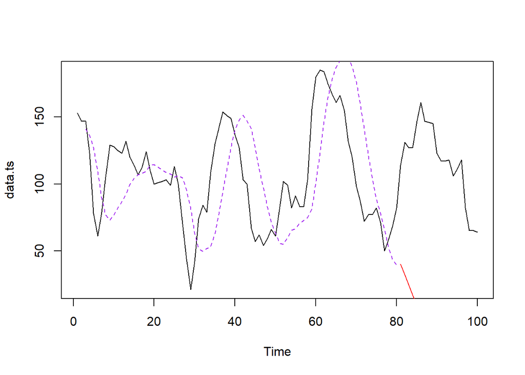

```r
plot(data.ts)
lines(des.1$fitted[,1], lty=2, col="purple")
lines(ramalandes1$mean, col="red")
```

Untuk mendapatkan nilai parameter optimum dari DES, argumen `alpha` dan `beta` dapat dibuat `NULL` seperti berikut.

```r
#Lamda dan gamma optimum
des.opt<- HoltWinters(train.ts, gamma = FALSE)
des.opt
```

```
## Holt-Winters exponential smoothing with trend and without seasonal component.
##
## Call:
## HoltWinters(x = train.ts, gamma = FALSE)
##
## Smoothing parameters:
##  alpha: 1
##  beta : 0.6870868
##  gamma: FALSE
##
## Coefficients:
##       [,1]
## a 82.00000
## b 11.33075
```

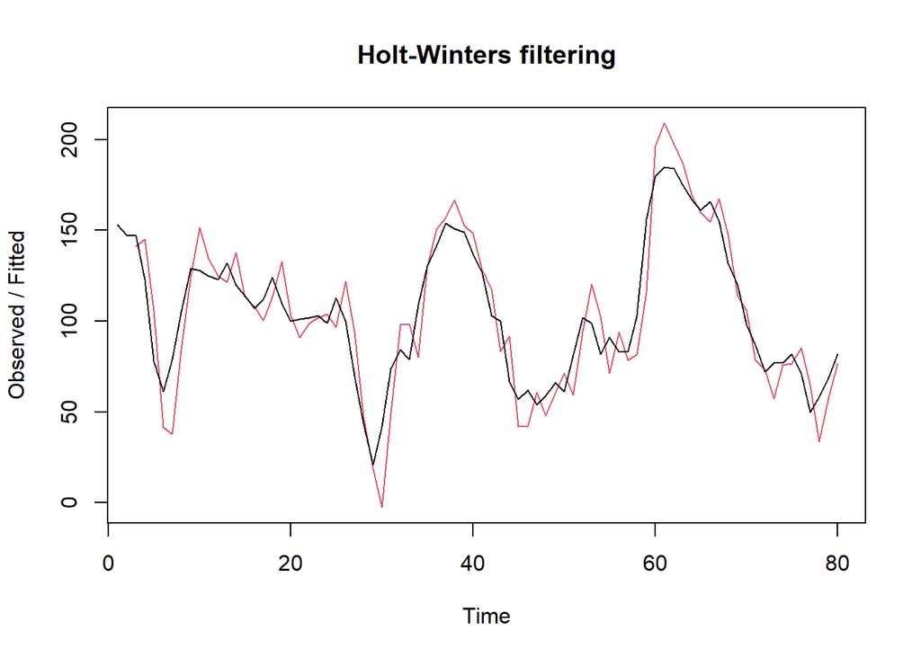

```r
plot(des.opt)
```

```r
#ramalan
ramalandesopt<- forecast(des.opt, h=20)
ramalandesopt
```

```
##     Point Forecast       Lo 80     Hi 80      Lo 95     Hi 95
##  81       93.33075   72.104736  114.5568   60.86836  125.7931
##  82      104.66151   63.033277  146.2897   40.99662  168.3264
##  83      115.99226   50.627973  181.3565   16.02621  215.9583
##  84      127.32301   35.156435  219.4896  -13.63360  268.2796
##  85      138.65376   16.896358  260.4112  -47.55812  324.8656
##  86      149.98452   -3.926002  303.8950  -85.40131  385.3703
##  87      161.31527  -27.127867  349.7584 -126.88364  449.5142
##  88      172.64602  -52.559134  397.8512 -171.77554  517.0676
##  89      183.97677  -80.094203  448.0478 -219.88493  587.8385
##  90      195.30753 -109.626178  500.2412 -271.04833  661.6634
##  91      206.63828 -141.062749  554.3393 -325.12456  738.4011
##  92      217.96903 -174.323202  610.2613 -381.99017  817.9282
##  93      229.29978 -209.336206  667.9358 -441.53607  900.1356
##  94      240.63054 -246.038142  727.2992 -503.66498  984.9261
##  95      251.96129 -284.371819  788.2944 -568.28942 1072.2120
##  96      263.29204 -324.285464  850.8695 -635.33021 1161.9143
##  97      274.62280 -365.731921  914.9775 -704.71523 1253.9608
##  98      285.95355 -408.668010  980.5751 -776.37845 1348.2855
##  99      297.28430 -453.053992 1047.6226 -850.25909 1444.8277
## 100      308.61505 -498.853146 1116.0833 -926.30099 1543.5311
```

Selanjutnya akan dilakukan perhitungan akurasi pada data latih maupun data uji dengan ukuran akurasi SSE, MSE dan MAPE.

#### Akurasi Data Latih

```r
#Akurasi Data Training
ssedes.train1<-des.1$SSE
msedes.train1<-ssedes.train1/length(train.ts)
sisaandes1<-ramalandes1$residuals
head(sisaandes1)
```

```
## Time Series:
## Start = 1
## End = 6
## Frequency = 1
## [1]        NA        NA   6.00000 -13.44000 -49.45440 -48.28774
```

```r
mapedes.train1 <- sum(abs(sisaandes1[3:length(train.ts)]/train.ts[3:length(train.ts)])
                      *100)/length(train.ts)

akurasides.1 <- matrix(c(ssedes.train1,msedes.train1,mapedes.train1))
row.names(akurasides.1)<- c("SSE", "MSE", "MAPE")
colnames(akurasides.1) <- c("Akurasi lamda=0.2 dan gamma=0.2")
akurasides.1
```

```
##      Akurasi lamda=0.2 dan gamma=0.2
## SSE                     123121.00222
## MSE                       1539.01253
## MAPE                        36.52108
```

```r
ssedes.train2<-des.2$SSE
msedes.train2<-ssedes.train2/length(train.ts)
sisaandes2<-ramalandes2$residuals
head(sisaandes2)
```

```
## Time Series:
## Start = 1
## End = 6
## Frequency = 1
## [1]        NA        NA   6.00000 -16.68000 -43.74960 -18.70251
```

```r
mapedes.train2 <- sum(abs(sisaandes2[3:length(train.ts)]/train.ts[3:length(train.ts)])
                      *100)/length(train.ts)

akurasides.2 <- matrix(c(ssedes.train2,msedes.train2,mapedes.train2))
row.names(akurasides.2)<- c("SSE", "MSE", "MAPE")
colnames(akurasides.2) <- c("Akurasi lamda=0.6 dan gamma=0.3")
akurasides.2
```

```
##      Akurasi lamda=0.6 dan gamma=0.3
## SSE                      38105.68282
## MSE                        476.32104
## MAPE                        20.04617
```

Berdasarkan hasil akurasi dari data latih, didapatkan bahwa skenario dengan parameter lamda = 0,6 dan gamma = 0,3 menghasilkan nilai MAPE sebesar 20,05%. Berdasarkan nilai MAPE tersebut, akurasi peramalan untuk skenario ini dapat dikategorikan sebagai peramalan yang layak atau cukup baik.

#### Akurasi Data Uji

```r
#Akurasi Data Testing
selisihdes1<-ramalandes1$mean-testing$SN
selisihdes1
```

```
## Time Series:
## Start = 81
## End = 100
## Frequency = 1
##  [1]  -74.03730  -98.70949 -102.38169 -110.05389 -137.72608 -159.39828
##  [7] -153.07048 -159.74267 -166.41487 -152.08707 -153.75926 -161.43146
## [13] -170.10366 -165.77585 -178.44805 -193.12024 -164.79244 -155.46464
## [19] -163.13683 -169.80903
```

```r
SSEtestingdes1<-sum(selisihdes1^2)
MSEtestingdes1<-SSEtestingdes1/length(testing$SN)
MAPEtestingdes1<-sum(abs(selisihdes1/testing$SN)*100)/length(testing$SN)

selisihdes2<-ramalandes2$mean-testing$SN
selisihdes2
```

```
## Time Series:
## Start = 81
## End = 100
## Frequency = 1
##  [1] -38.902963 -53.683063 -47.463162 -45.243262 -63.023362 -74.803461
##  [7] -58.583561 -55.363661 -52.143761 -27.923860 -19.703960 -17.484060
## [13] -16.264160  -2.044259  -4.824359  -9.604459  28.615441  47.835342
## [19]  50.055242  53.275142
```

```r
SSEtestingdes2<-sum(selisihdes2^2)
MSEtestingdes2<-SSEtestingdes2/length(testing$SN)
MAPEtestingdes2<-sum(abs(selisihdes2/testing$SN)*100)/length(testing$SN)

selisihdesopt<-ramalandesopt$mean-testing$SN
selisihdesopt
```

```
## Time Series:
## Start = 81
## End = 100
## Frequency = 1
##  [1] -20.6692473 -26.3384946 -11.0077419   0.3230108  -8.3462366 -11.0154839
##  [7]  14.3152688  26.6460215  38.9767742  72.3075269  89.6382796 100.9690323
## [13] 111.2997849 134.6305376 140.9612903 145.2920430 192.6227957 220.9535484
## [19] 232.2843011 244.6150538
```

```r
SSEtestingdesopt<-sum(selisihdesopt^2)
MSEtestingdesopt<-SSEtestingdesopt/length(testing$SN)
MAPEtestingdesopt<-sum(abs(selisihdesopt/testing$SN)*100)/length(testing$SN)

akurasitestingdes <-
  matrix(c(SSEtestingdes1,MSEtestingdes1,MAPEtestingdes1,SSEtestingdes2,MSEtestingdes2,
           MAPEtestingdes2,SSEtestingdesopt,MSEtestingdesopt,MAPEtestingdesopt),
         nrow=3,ncol=3)
row.names(akurasitestingdes)<- c("SSE", "MSE", "MAPE")
colnames(akurasitestingdes) <- c("des ske1","des ske2","des opt")
akurasitestingdes
```

```
##        des ske1    des ske2     des opt
## SSE  464000.501 37787.39235 298534.9007
## MSE   23200.025  1889.36962  14926.7450
## MAPE    140.152    35.12978    106.1053
```

#### Perbandingan SES dan DES

```r
MSEfull <-
  matrix(c(MSEtesting1,MSEtesting2,MSEtestingopt,MSEtestingdes1,MSEtestingdes2,
           MSEtestingdesopt),nrow=3,ncol=2)
row.names(MSEfull)<- c("ske 1", "ske 2", "ske opt")
colnames(MSEfull) <- c("ses","des")
MSEfull
```

```
##              ses      des
## ske 1   2275.661 23200.03
## ske 2   2327.255  1889.37
## ske opt 1963.689 14926.75
```

Berdasarkan perbandingan nilai MSE antara metode SES dan DES pada data uji (testing), terlihat hasil yang bervariasi. Pada Skenario 1 dan Skenario Optimal, metode SES menunjukkan kinerja yang lebih baik dengan nilai MSE yang jauh lebih kecil dibandingkan metode DES. Sebaliknya, pada Skenario 2, metode DES menghasilkan nilai MSE yang lebih rendah (1889,37) dibandingkan SES (2327,25), sehingga pada skenario tersebut metode DES lebih baik digunakan.

## Holt-Winters (Triple Exponential Smoothing)

Sunspot number tidak memiliki musiman kalender seperti data penjualan bulanan, namun secara fisis memiliki pola **kuasi-periodik** akibat **rotasi Matahari**: bintik matahari yang sama dapat kembali terlihat dari Bumi setiap kali Matahari berputar pada porosnya, yaitu sekitar **27 hari** (periode rotasi Carrington). Karena itu, pada percobaan ini frekuensi musiman diset `s = 27`.

```r
train.ts27 <- ts(training$SN, frequency = 27)
test.ts27  <- ts(testing$SN,  frequency = 27)
```

```r
# Model Winter aditif (fluktuasi musiman dianggap konstan)
winter.add <- HoltWinters(train.ts27, seasonal = "additive")
winter.add   # cek alpha, beta, gamma optimum
```

```
## Holt-Winters exponential smoothing with trend and additive seasonal component.
##
## Call:
## HoltWinters(x = train.ts27, seasonal = "additive")
##
## Smoothing parameters:
##  alpha: 1
##  beta : 0
##  gamma: 1
##
## Coefficients:
##            [,1]
## a    90.1906722
## b    -0.4973038
## s1  -38.3758573
## s2  -64.6351166
## s3  -87.2277092
## s4  -65.9684499
## s5  -32.3017833
## s6  -19.8203018
## s7  -23.0425240
## s8    8.6611797
## s9   31.2167353
## s10  44.5500686
## s11  58.1056241
## s12  55.7722908
## s13  54.1796982
## s14  42.2167353
## s15  17.7352538
## s16   1.7352538
## s17  -0.5980796
## s18   8.2908093
## s19  22.1056241
## s20   7.8834019
## s21  -2.7832647
## s22  -2.8943759
## s23  -2.8203018
## s24  -2.3017833
## s25  -7.2647462
## s26   5.7722908
## s27  -8.1906722
```

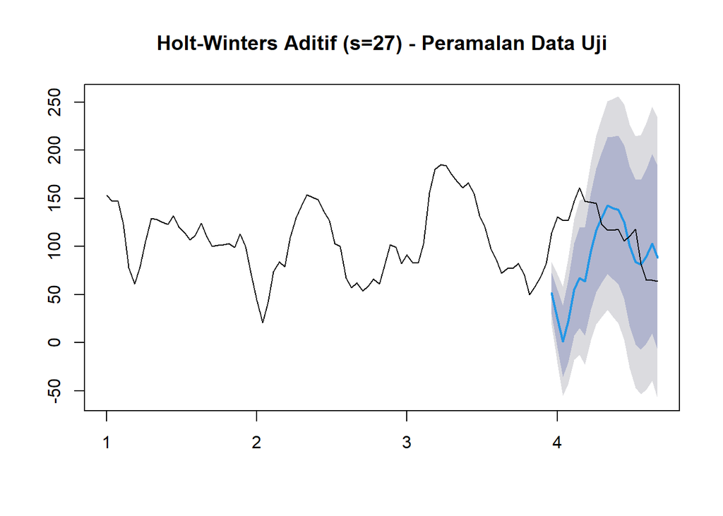

```r
ramalan.wadd <- forecast(winter.add, h = 20)
plot(ramalan.wadd, main = "Holt-Winters Aditif (s=27) - Peramalan Data Uji")
lines(ts(c(training$SN, testing$SN), frequency = 27), col = "black")
```

```r
# Model Winter multiplikatif (fluktuasi musiman proporsional terhadap level)
winter.mult <- HoltWinters(train.ts27, seasonal = "multiplicative")
winter.mult   # cek alpha, beta, gamma optimum
```

```
## Holt-Winters exponential smoothing with trend and multiplicative seasonal component.
##
## Call:
## HoltWinters(x = train.ts27, seasonal = "multiplicative")
##
## Smoothing parameters:
##  alpha: 1
##  beta : 0
##  gamma: 1
##
## Coefficients:
##           [,1]
## a   90.1512824
## b   -0.4973038
## s1   0.6355669
## s2   0.3984997
## s3   0.1909437
## s4   0.3828490
## s5   0.6856421
## s6   0.7978413
## s7   0.7640976
## s8   1.0731020
## s9   1.3010761
## s10  1.4416732
## s11  1.5902640
## s12  1.5708066
## s13  1.5570322
## s14  1.4322242
## s15  1.1665469
## s16  0.9975378
## s17  0.9788746
## s18  1.0649859
## s19  1.2011770
## s20  1.0631219
## s21  0.9598848
## s22  0.9585906
## s23  0.9591013
## s24  0.9638548
## s25  0.9176134
## s26  1.0375103
## s27  0.9095822
```

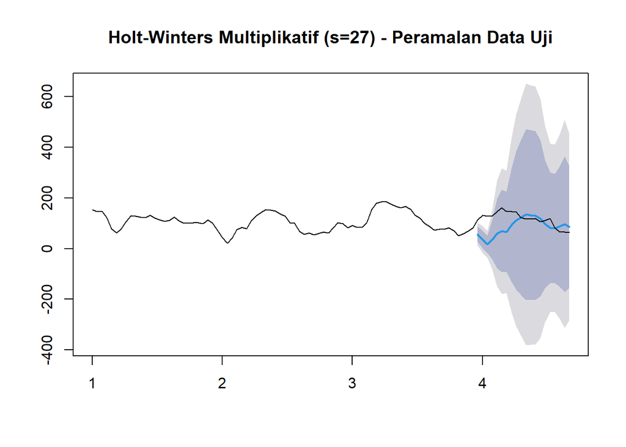

```r
ramalan.wmult <- forecast(winter.mult, h = 20)
plot(ramalan.wmult, main = "Holt-Winters Multiplikatif (s=27) - Peramalan Data Uji")
lines(ts(c(training$SN, testing$SN), frequency = 27), col = "black")
```

### Akurasi Metode Winter

```r
# Data latih
sse_wadd  <- winter.add$SSE;  mse_wadd  <- sse_wadd  / length(train.ts27);  rmse_wadd  <- sqrt(mse_wadd)
sse_wmult <- winter.mult$SSE; mse_wmult <- sse_wmult / length(train.ts27); rmse_wmult <- sqrt(mse_wmult)

akurasi_train.winter <- data.frame(
  Model = c("Winter Aditif (s=27)", "Winter Multiplikatif (s=27)"),
  SSE  = c(sse_wadd, sse_wmult),
  MSE  = c(mse_wadd, mse_wmult),
  RMSE = c(rmse_wadd, rmse_wmult)
)
akurasi_train.winter
```

```
##                         Model      SSE      MSE     RMSE
## 1        Winter Aditif (s=27) 14477.90 180.9737 13.45265
## 2 Winter Multiplikatif (s=27) 28472.46 355.9058 18.86547
```

```r
# Data uji
selisih_wadd  <- as.numeric(ramalan.wadd$mean)  - testing$SN
selisih_wmult <- as.numeric(ramalan.wmult$mean) - testing$SN

akurasi_test.winter <- data.frame(
  Model = c("Winter Aditif (s=27)", "Winter Multiplikatif (s=27)"),
  SSE  = c(sum(selisih_wadd^2), sum(selisih_wmult^2)),
  MSE  = c(mean(selisih_wadd^2), mean(selisih_wmult^2)),
  RMSE = c(sqrt(mean(selisih_wadd^2)), sqrt(mean(selisih_wmult^2))),
  MAPE = c(mean(abs(selisih_wadd/testing$SN))*100, mean(abs(selisih_wmult/testing$SN))*100)
)
akurasi_test.winter
```

```
##                         Model      SSE      MSE     RMSE     MAPE
## 1        Winter Aditif (s=27) 75393.78 3769.689 61.39779 40.22906
## 2 Winter Multiplikatif (s=27) 63919.01 3195.951 56.53274 36.31214
```

Data latih hanya berisi 80 observasi, yaitu kurang dari 3 siklus penuh jika musiman diasumsikan 27 hari. Estimasi komponen musiman pada metode Winter idealnya membutuhkan minimal 2–3 siklus penuh agar stabil, sehingga hasil di sini perlu dimaknai sebagai eksplorasi, bukan model musiman yang benar-benar teruji.

## Perbandingan Akhir dan Pemilihan Metode Terbaik

Perbandingan difokuskan pada **data uji** (bukan data latih), karena kinerja di data uji mencerminkan kemampuan generalisasi/peramalan metode terhadap data baru yang belum pernah “dilihat” model.

```r
perbandingan <- data.frame(
  Metode = c("SMA m=4", "DMA m=4", "SES alpha optimum", "DES optimum",
             "Winter Aditif (s=27)", "Winter Multiplikatif (s=27)"),
  SSE  = c(SSE_test.sma, SSE_test.dma, sum(eopt^2), sum(selisihdesopt^2),
           sum(selisih_wadd^2), sum(selisih_wmult^2)),
  MSE  = c(MSE_test.sma, MSE_test.dma, mean(eopt^2), mean(selisihdesopt^2),
           mean(selisih_wadd^2), mean(selisih_wmult^2)),
  MAPE = c(MAPE_test.sma, MAPE_test.dma, mean(abs(eopt/testing$SN))*100,
           mean(abs(selisihdesopt/testing$SN))*100,
           mean(abs(selisih_wadd/testing$SN))*100, mean(abs(selisih_wmult/testing$SN))*100)
)
perbandingan[order(perbandingan$MAPE), ]
```

```
##                        Metode       SSE       MSE      MAPE
## 3           SES alpha optimum  39273.78  1963.689  32.22567
## 6 Winter Multiplikatif (s=27)  63919.01  3195.951  36.31214
## 5        Winter Aditif (s=27)  75393.78  3769.689  40.22906
## 1                     SMA m=4  69063.75  3453.188  40.24882
## 2                     DMA m=4  79945.50  3997.275  46.31214
## 4                 DES optimum 298534.90 14926.745 106.10526
```